# 2025 Final Report

- Show All Code
- Hide All Code
- View Source

Predicting volatility

Author

Emily Lin

Published

June 1, 2025

https://github.com/emilyl523/OPTIVER11

# Executive Summary

> Traditional volatility forecasting models like EGARCH, while statistically rigorous, struggle with the speed, noise, and complexity of modern high-frequency markets. As trading demands real-time responsiveness, reliance on lagged prices misses dynamic signals in live order book data.

This project investigates whether machine learning models trained on high-frequency order book features can outperform traditional econometric approaches in short-term volatility forecasting. Using second-by-second data from anonymous stocks, we engineered domain-informed features—capturing momentum, spread, and latent liquidity—and trained models including LightGBM, XGBoost, Random Forest, and robust regression.

These insights power **EchoVol20**—an interactive dashboard that delivers real-time volatility forecasts using high-frequency order book data. Designed for rapid deployment, it embodies a fast, adaptive, and practical approach to short-term market risk prediction.

# Introduction

Volatility, the extent of variation in asset returns, plays a pivotal role in pricing derivatives, allocating portfolios, and managing risk (Bhambu et al. (2025)). Yet in modern markets—where prices shift in milliseconds—volatility remains exceptionally hard to forecast.

> In 2024, a sudden rise in market uncertainty led to over $4 billion in losses for products positioned against volatility (Mackenzie (2024)). Events like this highlight the need for faster, more adaptive forecasting tools.

Historically, volatility modelling has been led by Generalised Autoregressive Conditional Heteroskedasticity (GARCH) models, which exploit patterns in past returns. Exponential GARCH (EGARCH) builds on this by incorporating asymmetries, such as the stronger impact of negative shocks on future volatility (Nelson (1991)). However, these models assume stationarity and rely on linear dynamics, limiting their effectiveness in high-frequency environments characterised by rapid regime shifts and nonlinear interactions (Mohammad and Mudhir (2020)).

With the rise of high-frequency trading, volatility forecasting has become a high-resolution problem. Order book data now provides real-time signals—like price imbalances, liquidity shifts, and spread changes—that often precede volatility spikes (Abergel et al. (2016)). Machine learning (ML) models are well-suited to extract patterns from such high-dimensional, noisy data.

**Important**

**Research Question**

**Do machine learning models trained on high-frequency order book data provide more accurate and timely short-term volatility forecasts than traditional econometric approaches?**

To answer this, we conduct a systematic comparative study of:

- **EGARCH**: A benchmark econometric model designed to capture volatility asymmetries.
- **LightGBM** and **XGBoost**: Gradient boosting frameworks capable of modelling complex nonlinearities and interactions in noisy, high-frequency data.
- Other contenders: Including **Random Forest** and robust linear models such as **Huber Regressor.**

As markets automate, real-time volatility forecasting becomes essential for both performance and resilience. This study bridges traditional models and machine learning to show how high-frequency data can sharpen our view of market dynamics.

# Method Overview

Our methodology, summarized in Figure 1, begins with the collection of order book data for 126 anonymized stocks. Stocks were segmented into high, low, and general volatility cohorts based on average realized volatility. From each group, representative stocks and 100 `time_ids` were sampled to construct a unified yet volatility-diverse training dataset.

Next, we performed domain-driven feature engineering tailored to the microstructure of limit order books. Core predictive signals such as the volume-weighted average price (WAP), log returns, bid-ask spread deltas, volume-weighted volatility, and noise ratios were derived to capture transient liquidity stress and price momentum.

We then evaluated five model classes under controlled settings, each being assessed using rigorous metrics—RMSE, MAE, Mean Directional Accuracy (MDA), and prediction latency—to balance statistical precision with deployment viability.

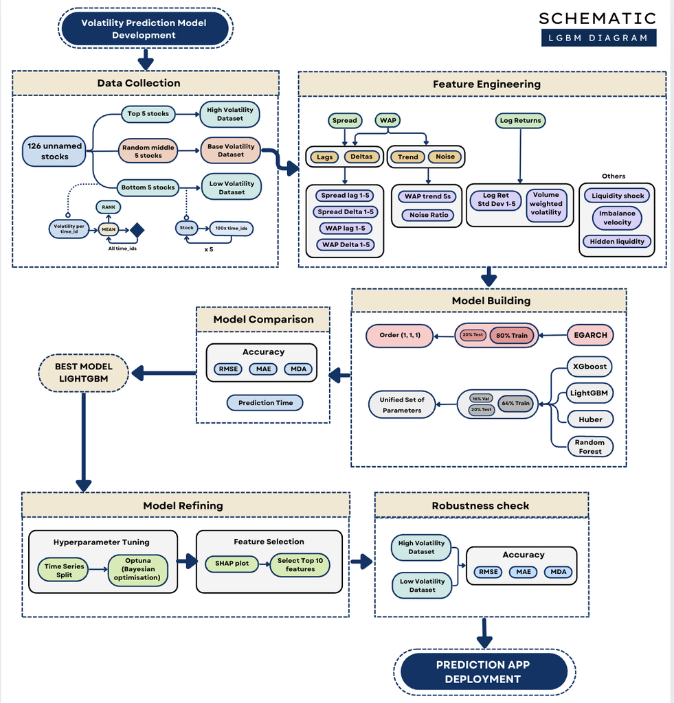

Figure 1: End-to-end pipeline from data sampling and feature engineering to model selection, tuning, and deployment for real-time volatility forecasting.

# Data Collection

```python
# import all libraries needed to generate plots
# Standard libraries including for plotting
import numpy as np
import pandas as pd
import matplotlib.pyplot as plt
import seaborn as sns
import matplotlib.gridspec as gridspec
import warnings
from sklearn.exceptions import ConvergenceWarning
from sklearn.model_selection import TimeSeriesSplit
import optuna
import shap

# import all model libraries
import lightgbm as lgb
import xgboost as xgb
from sklearn.linear_model import HuberRegressor
from sklearn.ensemble import RandomForestRegressor
from arch import arch_model

# import metrics
from sklearn.metrics import mean_squared_error, mean_absolute_error
import time
import plotly.express as px
import plotly.graph_objects as go

from matplotlib.ticker import LogLocator
```

## Data Overview

**Primary Training Dataset: High-Frequency Anonymized Order Book Data**

We use a proprietary dataset containing high-frequency order book snapshots from 126 anonymised stocks. Each record is grouped by a unique `time_id`, representing an unspecified time segment within a trading day. These `time_id`s are neither sequential nor linked to actual timestamps, preventing direct temporal aggregation for standard time-series modeling.

Within each `time_id`, bid-ask prices and volumes are recorded at a second-level resolution for up to 600 seconds (simulating a 10-minute trading window). However, gaps exist due to intermittent recording—typical in high-frequency systems.

Due to the computational cost of processing full-depth order books across all stocks, we selected a representative random sample of five. This mirrors real-world scenarios where models must generalize to new instruments with sparse historical data.

**Volatility-Stratified Subsets for Regime Evalutation**

To test model robustness under varying market conditions, we constructed three volatility-based subsets by stratifying the data according to average realised volatility per `time_id`. These subsets were ranked based on each stock’s overall average volatility (see `stock_ranking.py` for ranking logic).

- High-Volatility Dataset `df_high`: Top 5 stocks
- Low-Volatility Dataset `df_low`: Bottom 5 stocks
- General Dataset `df_general`: Random selection of 5 stocks in neither extreme groups, used as a baseline for model development.

Each subset contains 100 randomly sample `time_id` per stock, concatenated into one final labeled dataset using a common preprocessing function. All stocks were verified there were sufficient number of `time_id` and no further filtering was required.

```python
def generate_representative_dataset(stock_files, label, sample_size=100, seed=42):
    np.random.seed(seed)
    sampled_dfs = []

    for file in stock_files:
        stock_df = pd.read_csv(file)
        stock_name = file.split('.')[0]
        sampled_ids = np.random.choice(stock_df['time_id'].unique(), size=sample_size, replace=False)
        sampled_df = stock_df[stock_df['time_id'].isin(sampled_ids)].copy()
        sampled_df['stock_name'] = stock_name
        sampled_df['dataset_label'] = label
        sampled_dfs.append(sampled_df)

    return pd.concat(sampled_dfs, ignore_index=True)

general_stocks = ['stock_39.csv', 'stock_47.csv', 'stock_61.csv', 'stock_84.csv', 'stock_93.csv']
high_vol_stocks = ['stock_6.csv', 'stock_27.csv', 'stock_75.csv', 'stock_80.csv', 'stock_18.csv']
low_vol_stocks = ['stock_41.csv', 'stock_43.csv', 'stock_29.csv', 'stock_46.csv', 'stock_125.csv']

df_general = generate_representative_dataset(general_stocks, label='general')
df_high = generate_representative_dataset(high_vol_stocks, label='high')
df_low = generate_representative_dataset(low_vol_stocks, label='low')
```

**Additional Dataset of App Deployment** For real-world deployment, we integrated a complementary dataset provided by Optiver. This includes real stocks such as Apple and Amazon, along with identifiable tickers and sequential time_ids mapped to real timestamps. This dataset was used in the interactive application to simulate predictions in a production-like setting.

## Data Preprocessing

Our target variable—realized volatility—was constructed by aggregating log returns over each `time_id`. Log returns were derived using the WAP, given by:
$$r_t = \log{(\text{WAP}_t)} - \log{(\text{WAP}_{t-1})}$$

Due to the non-sequential nature of `time_id`s, return-based calculations were constrained to within individual `time_id`s only. This design choice preserves the integrity of within-segment volatility dynamics and avoids false assumptions of temporal continuity.

Missing WAP values led to undefined returns; in such cases, we replaced NaN log returns with 0, effectively indicating no price movement. While simplistic, this imputation reflects the common assumption in high-frequency settings that missing ticks represent moments of inactivity. We acknowledge that this may understate micro-level volatility, but it ensures computational tractability and model compatibility.

Each `time_id` was into 20-second intervals, chosen to align with real-time decision horizons in high-frequency trading. Realised volatility over each 20-second window was computed as the square root of the sum of squared log returns:
$$RV_{[t,t+20]} = \sqrt{\sum_{i=t}^{t+19} r_i^2}$$
This approach captures short-term market turbulence while smoothing out momentary spikes.

```python
def compute_wap(df):
    """Compute Weighted Average Price (WAP) from top-of-book quotes."""
    return (df['bid_price1'] * df['ask_size1'] +
            df['ask_price1'] * df['bid_size1']) / (df['bid_size1'] + df['ask_size1'])

def compute_log_returns(wap_series):
    """Compute log returns, replacing NaNs (from diff) with 0."""
    return np.log(wap_series).diff().fillna(0)

def compute_realized_volatility(returns, window_size=20):
    """
    Compute realized volatility over rolling windows (default 20 seconds).
    Assumes input `returns` is a time-ordered Series per time_id.
    Returns a Series of realized volatility values.
    """
    return returns.rolling(window_size).apply(lambda x: np.sqrt(np.sum(x**2)), raw=True).dropna()
```

## Feature Engineering

To ensure a fair model comparison, we constructed a unified feature set using only Level 1 and Level 2 order book data, targeting early indicators of short-term volatility. Each feature class reflects a distinct mechanism driving price instability.

1. **Volatility Memory**:

Rolling standard deviations of WAP log returns (1–5s) capture short-term persistence in return variability—crucial for anticipating clustered volatility.

2. **Price Momentum and Directionality**:

Lagged WAP values and first differences model emerging directional trends. A rolling trend estimate over 5s highlights sustained drifts preceding volatility spikes.

3. **Microstructure Frictions**:

Spread levels and deltas indicate rising execution risk and liquidity withdrawal—early signals of market stress.

4. **Latent liquidity and Order Book Pressure**:

Imbalance velocity, noise ratios, and volume-weighted volatility reveal hidden stress in order flow. These nonlinear signals are particularly effective for tree-based models.

```python
def add_return_features(df):
    for i in range(1, 6):
        df[f'log_ret_std_{i}'] = df['log_ret'].shift(1).rolling(window=i, min_periods=1).std()
    return df

def add_wap_features(df):
    for lag in range(1, 6):
        df[f'wap_lag_{lag}'] = df['WAP'].shift(lag)
        df[f'wap_delta_{lag}'] = df['WAP'] - df[f'wap_lag_{lag}']
    df['wap_trend_5s'] = df[[f'wap_delta_{i}' for i in range(1, 6)]].mean(axis=1)
    return df

def add_spread_features(df):
    df['spread'] = (df['ask_price1'] - df['bid_price1']) / df['ask_price1']
    for lag in range(1, 6):
        df[f'spread_lag_{lag}'] = df['spread'].shift(lag)
        df[f'spread_delta_{lag}'] = df['spread'] - df[f'spread_lag_{lag}']
    return df

def add_liquidity_features(df):
    df['liquidity_shock'] = df['bid_size1'].rolling(5).std() / df['bid_size1'].rolling(20).mean()
    df['imbalance_velocity'] = ((df['bid_size1'] - df['ask_size1']) / (df['bid_size1'] + df['ask_size1'])).diff().rolling(3).mean()
    df['vol_weighted_vol'] = df['log_ret'].abs() * df['bid_size1'].rolling(10).sum()
    df['noise_ratio'] = df['ask_price1'].diff().abs() / df['WAP'].diff().abs().rolling(5).std()
    df['hidden_liquidity'] = (df['bid_size2'] + df['ask_size2']) / (df['bid_size1'] + df['ask_size1'])
    return df
```

# Model Candidates

In selecting our candidate models, we aimed to span a large spectrum of volatility forecasting paradigms—comparing advanced machine learning to a traditional benchmark EGARCH, with simpler models chosen to provide context for incremental gains and diagnostic insight.

**Machine Learning Models: Capturing Nonlinear Microstructure Dynamics**

- **LightGBM** (Ke et al. (2017)): A fast, memory-efficient gradient booster using leaf-wise growth and histogram-based binning—well-suited to high-dimensional, sparse order book signals.
- **XGBoost** (Chen and Guestrin (2016)): A widely used gradient booster with level-wise tree construction and strong regularisation.

Both models target complex, transient patterns characteristic of short-horizon volatility.

**Reference Models: Interpretability and Diagnostic Insight**

1. **Random Forest** (Breiman (2001)): An ensemble of decorrelated trees offering a non-boosted baseline. Its comparison to LightGBM and XGBoost isolates the contribution of boosting.
2. **Huber Regression** (Feng and Wu (2022)): A robust linear model tested for its ability to extract stable relationships from noisy microstructure features.

# Model Training and Testing

## Machine Learning Models

We developed a time-consistent training pipeline tailored to high-frequency volatility prediction (see Appendix A for pipeline). It enforces no information leakage, supports lag-based features, and is robust to common pathologies in order book data.

**Data Imputation and Preprocessing**

Log and ratio transformations often produced infinities. We treated these as missing values, then applied forward- and back-filling within each `time_id`. Remaining gaps were filled with zero to preserve continuity without introducing noise.

```python
# Function that creates all features defined above at once
def engineer_features(df):
    df = add_return_features(df)
    df = add_wap_features(df)
    df = add_spread_features(df)
    df = add_liquidity_features(df)
    df = df.replace([np.inf, -np.inf], np.nan)
    return df.ffill().bfill().fillna(0)
```

**Time-Aware Splitting**

Each `time_id` was split by `seconds_in_bucket`:

- First 64% → training
- Next 16% → validation
- Final 20% → testing

The first 5 seconds were excluded from all sets to avoid lookahead in lagged features.

```python
# Function for splitting into train/val/test sets
def split_data(df, feature_cols, target_col='log_ret'):
    df = df[df['seconds_in_bucket'] >= 5].reset_index(drop=True)
    train_val_mask = df['seconds_in_bucket'] <= 480
    test_mask = df['seconds_in_bucket'] > 480
    train_mask = df['seconds_in_bucket'] <= 480 * 0.8
    val_mask = (df['seconds_in_bucket'] > 480 * 0.8) & train_val_mask

    return (
        df[train_mask][feature_cols], df[train_mask][target_col],
        df[val_mask][feature_cols], df[val_mask][target_col],
        df[test_mask][feature_cols], df[test_mask][target_col],
        df[test_mask]
    )
```

**Model Configuration** All tree-based models used shallow depths (`max_depth=5`) and conservative learning rates (`0.03`) to limit overfitting on noisy signals. Gradient boosting models were tuned with early stopping, while Huber regression used default robustness settings. All models followed a common parameter structure:

```python
# Consistent parameters to feed in each model, based on theory
BASE_PARAMS = {
    "lightgbm": {
        "learning_rate": 0.03,
        "num_leaves": 31,
        "max_depth": 5,
        "min_data_in_leaf": 20,
        "feature_fraction": 0.8,
        "bagging_freq": 10,
        "verbosity": -1,
        "lambda_l2": 0
    },
    "xgboost": {
        'objective': 'reg:squarederror',
        'eval_metric': 'mae',
        "learning_rate": 0.03,
        "max_depth": 5,
        "min_child_weight": 5,
        "subsample": 0.8
    },
    "random_forest": {
        "max_depth": 5,
        "min_samples_leaf": 20,
        "n_estimators": 300
    },
    "huber": {
        "epsilon": 1.35,
        "max_iter": 500
    }
}
```

During evaluation, each model predicted log returns over the final 120 seconds of each `time_id`, grouped into six 20-second windows. Realised volatility was computed per window and aggregated to evaluate model performance.

## EGARCH Model

The EGARCH(1,1,1) model was trained on 80% of raw log returns and tested on the final 20% (see Appendix B for training pipeline). Returns were scaled by $10^4$ to improve numerical stability. The model specification included:

- GARCH ($1$): Capturing volatility persistence.
- ARCH ($1$): Accounting for immediate return shocks.
- Asymmetric term ($1$): Leverage effects in volatility response.

  **Warning**

  Despite stabilisation efforts, convergence issues occasionally occurred—reflecting the fragility of parametric models on irregular, heavy-tailed high-frequency data.

# Evaluation Metrics

Model performance was assessed using three key metrics: **Root Mean Squared Error (RMSE)**, **Mean Absolute Error (MAE)**, and **Mean Directional Accuracy (MDA)**.

- **RMSE** (Chai and Draxler (2014)) amplifies large errors, making it ideal for risk-aware applications where major mispredictions could lead to disruptive trades.
- **MAE** (Chai and Draxler (2014)) offers a noise-tolerant alternative by averaging absolute deviations, better reflecting performance under typical high-frequency noise.
- **MDA** (Patton and Sheppard (2009)) evaluates whether the model correctly predicts the *direction* of volatility changes—crucial for anticipating market regime shifts and informing position management.

In addition to accuracy, we also recorded prediction times, as latency is a critical constraint in high-frequency settings

```python
# Newly defined MDA function
def calculate_mda(actual, predicted):

    actual = np.array(actual)
    predicted = np.array(predicted)

    actual_diff = np.diff(actual)
    actual_signs = np.sign(actual_diff)
    predicted_diff = np.diff(predicted)
    predicted_signs = np.sign(predicted_diff)

    num_correct = np.sum(actual_signs == predicted_signs)
    mda = num_correct / (len(actual) - 1)

    return mda
```

# Results

**Machine Learning Models Outperform Traditional Approaches**

In contrast, EGARCH performed weakest across all metrics: RMSE and MAE were orders of magnitude higher, and directional accuracy fell to $49.45\%$, below the level of random guessing. This gap highlights the limitations of traditional econometric models when applied to high-frequency, non-stationary data streams.

All machine learning models—including XGBoost, Random Forest, and Huber Regression—consistently outperformed EGARCH across accuracy and directionality metrics.

**Comparative Insights: Boosting, Bagging, and Linear Robustness**

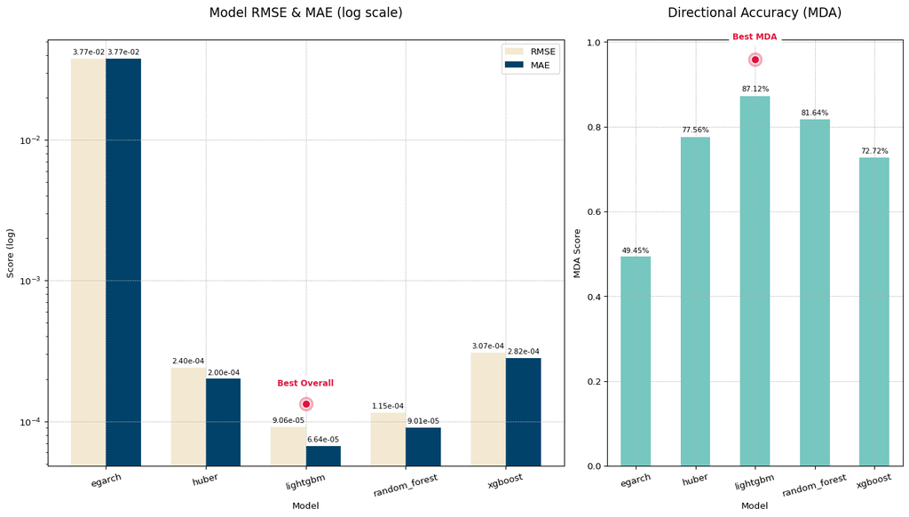

Figure 2

```python
# Load data
final_metrics = pd.read_csv("model_results/final_metrics.csv")
avg_metrics_df = final_metrics.groupby("model")[["rmse", "mae", "mda", "prediction_time"]].mean().reset_index()

# Setup
model_order = ["egarch", "huber", "lightgbm", "random_forest", "xgboost"]
metrics = ["rmse", "mae"]
colors = {"rmse": "#f3e9d2", "mae": "#01426a", "mda": "#76c7c0"}

# Sort models
avg_metrics_df["model"] = pd.Categorical(avg_metrics_df["model"], categories=model_order, ordered=True)
avg_metrics_df = avg_metrics_df.sort_values("model")

# Create figure
fig, (ax1, ax2) = plt.subplots(1, 2, figsize=(14, 8), gridspec_kw={'width_ratios': [3.5, 2]})

# --- LEFT: RMSE + MAE ---
x = np.arange(len(model_order))
width = 0.35
rmse_vals = avg_metrics_df["rmse"].values
mae_vals = avg_metrics_df["mae"].values

# Bars
bar1 = ax1.bar(x - width/2, rmse_vals, width, label='RMSE', color=colors["rmse"])
bar2 = ax1.bar(x + width/2, mae_vals, width, label='MAE', color=colors["mae"])

# Log scale and grid
ax1.set_yscale('log')
ax1.set_xticks(x)
ax1.set_xticklabels(model_order, rotation=15)
ax1.set_title("Model RMSE & MAE (log scale)", fontsize=14, pad=25)
ax1.set_ylabel("Score (log)")
ax1.set_xlabel("Model")
ax1.legend()
ax1.grid(True, axis='y', linestyle='--', linewidth=0.5)
ax1.grid(True, axis='x', linestyle='--', linewidth=0.5)

# Labels
for bars in [bar1, bar2]:
    for bar in bars:
        height = bar.get_height()
        ax1.text(bar.get_x() + bar.get_width()/2, height * 1.05,
                 f"{height:.2e}", ha='center', va='bottom', fontsize=8)

# Highlight best
totals = rmse_vals + mae_vals
best_idx = np.argmin(totals)
avg_y = (rmse_vals[best_idx] + mae_vals[best_idx]) / 2
ax1.scatter(best_idx, avg_y * 1.7, s=220, color="crimson", alpha=0.3, zorder=5)
ax1.scatter(best_idx, avg_y * 1.7, s=80, color="crimson", zorder=6, edgecolor='white', linewidth=1)
ax1.text(best_idx, avg_y * 2.2, "Best Overall", ha='center', va='bottom',
         fontsize=9, fontweight='bold', color="crimson", backgroundcolor="white")

# --- RIGHT: MDA ---
mda_vals = avg_metrics_df["mda"].values
bar3 = ax2.bar(x, mda_vals, width=0.5, color=colors["mda"])

ax2.set_xticks(x)
ax2.set_xticklabels(model_order, rotation=15)
ax2.set_title("Directional Accuracy (MDA)", fontsize=14, pad=25)
ax2.set_ylabel("MDA Score")
ax2.set_xlabel("Model")
ax2.grid(True, axis='y', linestyle='--', linewidth=0.5)
ax2.grid(True, axis='x', linestyle='--', linewidth=0.5)

# Labels
for bar in bar3:
    height = bar.get_height()
    ax2.text(bar.get_x() + bar.get_width()/2, height * 1.01,
             f"{height:.2%}", ha='center', va='bottom', fontsize=8)

# Highlight best
best_mda_idx = np.argmax(mda_vals)
ax2.scatter(best_mda_idx, mda_vals[best_mda_idx] * 1.1, s=220, color="crimson", alpha=0.3, zorder=5)
ax2.scatter(best_mda_idx, mda_vals[best_mda_idx] * 1.1, s=80, color="crimson", zorder=6, edgecolor='white', linewidth=1)
ax2.text(best_mda_idx, mda_vals[best_mda_idx] * 1.15, "Best MDA", ha='center', va='bottom',
         fontsize=9, fontweight='bold', color="crimson", backgroundcolor="white")

# Final layout
fig.tight_layout()
plt.show()
plt.close()
```

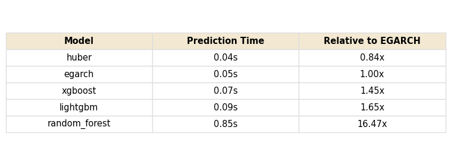

Figure 3

```python
# Prepare data
df_time = avg_metrics_df[['model', 'prediction_time']].copy()
df_time['relative_to_egarch'] = df_time['prediction_time'] / df_time[df_time['model'] == 'egarch']['prediction_time'].values[0]
df_time['relative_to_egarch'] = df_time['relative_to_egarch'].apply(lambda x: f"{x:.2f}x")
df_time['prediction_time'] = df_time['prediction_time'].apply(lambda x: f"{x:.2f}s")
df_time = df_time.sort_values('prediction_time').reset_index(drop=True)

# Create figure
fig, ax = plt.subplots(figsize=(8, 3))
ax.axis('off')

# Create table
table = ax.table(
    cellText=df_time.values,
    colLabels=["Model", "Prediction Time", "Relative to EGARCH"],
    loc='center',
    cellLoc='center'
)

# Style table
table.auto_set_font_size(False)
table.set_fontsize(11)
table.scale(1, 1.5)  # Adjust cell padding

# Header style
for (row, col), cell in table.get_celld().items():
    if row == 0:  # Header row
        cell.set_text_props(weight='bold')
        cell.set_facecolor('#f3e9d2')  # Light gray header
    cell.set_edgecolor('#dddddd')  # Border color

plt.tight_layout()
plt.show()
```

# Hyperparameter Tuning

Given its strong out-of-the-box performance, we further refined **LightGBM** through systematic hyperparameter tuning aimed at maximising both predictive accuracy and robustness under real-world, high-frequency conditions.

To achieve this, we developed a robust and time-aware tuning pipeline combining three core components:

1. **Temporal Integrity with `TimeSeriesSplit` Cross Validation**

We employed **`TimeSeriesSplit`** cross-validation to preserve chronological structure and avoid lookahead bias. Each training fold strictly preceded its corresponding validation set, replicating realistic forecasting conditions.

2. **Efficient Hyperparameter Optimisation with `optuna`**

Hyperparameters were tuned using **`optuna`**, an efficient Bayesian optimisation framework (Akiba et al. (2019)) . Compared to traditional grid or random search, Optuna accelerated convergence and reduced computational cost via:

**Note**

- **Adaptive learning** that targeted high-performing regions,
- **Early stopping** for poor-performing trials, and
- **Parallel execution** across trials.

This allowed broader, deeper exploration of LightGBM’s parameter space without compromising evaluation rigor.

3. **Stable Evaluation via RMSE averaging**

```python
# LightGBM model
df_general = pd.read_csv("vol_subsets/df_general.csv")
X_all, y_all = [], []
for (stock, time_id), df_subset in df_general.groupby(['stock_name', 'time_id']):
        df = df_subset.copy()
        df['WAP'] = compute_wap(df)
        df['log_ret'] = compute_log_returns(df['WAP'])
        df = engineer_features(df)

        feature_cols = [f'log_ret_std_{i}' for i in range(1, 6)] + \
        [f'wap_lag_{i}' for i in range(1, 6)] + \
        [f'wap_delta_{i}' for i in range(1, 6)] + \
        ['wap_trend_5s'] + ['spread'] + \
        [f'spread_lag_{i}' for i in range(1, 6)] + \
        [f'spread_delta_{i}' for i in range(1, 6)] + \
        ['liquidity_shock', 'imbalance_velocity', 'vol_weighted_vol', 'noise_ratio', 'hidden_liquidity']

        X_train, y_train, *_ = split_data(df, feature_cols)
        X_all.append(X_train)
        y_all.append(y_train)

X_train_all = pd.concat(X_all).sort_index()
y_train_all = pd.concat(y_all).sort_index()

# TimeseriesSplit with optuna
def objective(trial):
    params = {
        'objective': 'regression',
        'metric': 'rmse',
        'verbosity': -1,
        'boosting_type': 'gbdt',
        'num_leaves': trial.suggest_categorical('num_leaves', [20, 31, 40, 50]),
        'max_depth': trial.suggest_int('max_depth', 3, 7),
        'learning_rate': trial.suggest_float('learning_rate', 0.01, 0.05, step=0.01),
        'feature_fraction': trial.suggest_float('feature_fraction', 0.7, 1.0, step=0.1),
        'bagging_fraction': trial.suggest_float('bagging_fraction', 0.7, 1.0, step=0.1),
        'min_data_in_leaf': trial.suggest_int('min_data_in_leaf', 20, 60, step=10),
        'lambda_l1': trial.suggest_float('lambda_l1', 0.0, 1.0, step=0.1),
        'lambda_l2': trial.suggest_float('lambda_l2', 0.0, 1.0, step=0.1),
    }

    tscv = TimeSeriesSplit(n_splits=5)
    scores = []
    for train_idx, val_idx in tscv.split(X_train_all):
        X_t, X_v = X_train_all.iloc[train_idx], X_train_all.iloc[val_idx]
        y_t, y_v = y_train_all.iloc[train_idx], y_train_all.iloc[val_idx]

        lgb_train = lgb.Dataset(X_t, y_t)
        lgb_valid = lgb.Dataset(X_v, y_v, reference=lgb_train)

        model = lgb.train(
            params,
            lgb_train,
            valid_sets=[lgb_valid],
            num_boost_round=300,
            callbacks=[lgb.early_stopping(20), lgb.log_evaluation(0)])

        y_pred = model.predict(X_v, num_iteration=model.best_iteration)
        score = mean_squared_error(y_v, y_pred)
        scores.append(score)

    return np.mean(scores)

study = optuna.create_study(direction='minimize', sampler=optuna.samplers.TPESampler(seed=42))
study.optimize(objective, n_trials=50, show_progress_bar=True)
```

# Feature Selection

We applied SHAP (SHapley Additive Explanations) (Louhichi et al. (2023)) to the optimised LightGBM model to assess feature contributions across the test set. Figure 4 displays the top ten features ranked by mean absolute SHAP value.

```python
# Final model fit using best parameters
best_params = study.best_params
best_params.update({'objective': 'regression', 'metric': 'rmse', 'verbosity': -1})

# Final model fit on all data (no early stopping)
model = lgb.train(
    best_params,
    lgb.Dataset(X_train_all, label=y_train_all),
    num_boost_round=300,
    callbacks=[lgb.log_evaluation(0)]
)

# SHAP Analysis
explainer = shap.Explainer(model)
shap_values = explainer(X_train_all)

shap_df = pd.DataFrame(shap_values.values, columns=feature_cols)
shap_mean = shap_df.abs().mean().sort_values(ascending=False)
```

**Microstructure Features Dominate**

Volatility predictions were driven primarily by ultra-recent WAP changes—especially `wap_delta_1`, whose SHAP value was over 10× greater than any other feature. This supports our view that short-term volatility stems from immediate order book imbalances, not historical returns. Successive `wap_delta_k` features (2–5) also ranked highly, capturing rapid momentum shifts crucial for detecting volatility spikes.

**Liquidity and Noise Signals**

Features such as `vol_weighted_vol` and `noise_ratio` contributed meaningfully, reflecting liquidity-sensitive volatility and the destabilising effect of conflicting quote signals. These reinforce the role of order flow quality in anticipating abrupt market movements.

**Supporting Context**

Lower-ranked features, including `wap_lag_1` and `spread_delta_1`, offered contextual information but had substantially less influence. Their limited contribution underscores a key result: effective volatility prediction in high-frequency settings depends primarily on instantaneous, not historical, signals.

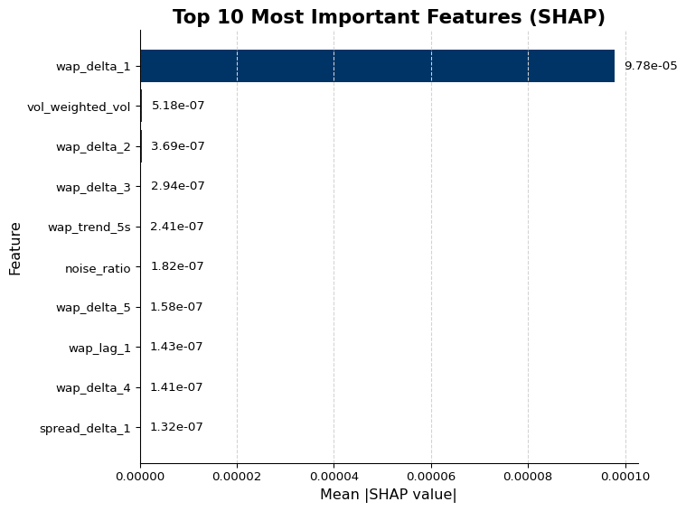

Figure 4

```python
shap_mean = pd.read_csv("shap_mean_importance.csv", index_col=0, header=None)
shap_mean.columns = ['mean_abs_shap']
top_10_df = shap_mean.sort_values(by='mean_abs_shap', ascending=False).head(10)
top_10_df = top_10_df[::-1]

# Plot SHAP values
fig, ax = plt.subplots(figsize=(8, 6))
bars = ax.barh(top_10_df.index, top_10_df['mean_abs_shap'], color="#003366")

# Add text at the end of bars
offset = top_10_df['mean_abs_shap'].max() * 0.02
for bar, value in zip(bars, top_10_df['mean_abs_shap']):
    ax.text(bar.get_width() + offset, bar.get_y() + bar.get_height()/2,
            f"{value:.2e}", va='center', ha='left', fontsize=10)

# Style
ax.set_title('Top 10 Most Important Features (SHAP)', fontsize=16, weight='bold')
ax.set_xlabel('Mean |SHAP value|', fontsize=12)
ax.set_ylabel('Feature', fontsize=12)
ax.set_facecolor('white')
ax.grid(axis='x', linestyle='--', color='lightgray')
ax.spines[['top', 'right']].set_visible(False)
fig.tight_layout()
plt.show()
```

# Robustness Check and Generalisability

We tested LightGBM on separate high- and low-volatility subsets (`df_high` and `df_low`). It outperformed the full-sample baseline on the low-volatility data, showing strong generalisation in stable markets. Performance declined on the high-volatility subset, reflecting challenges in capturing sharp spikes with static-tree models (see Appendix C). Despite this, LightGBM remains effective for risk-aware trading in low- to moderate-volatility conditions.

```python
high_vol_metrics = pd.read_csv("model_results/high_rv_metrics.csv")
low_vol_metrics = pd.read_csv("model_results/low_rv_metrics.csv")
high_summary = high_vol_metrics[['rmse', 'mae', 'mda']].mean().to_frame(name='High Volatility')
low_summary = low_vol_metrics[['rmse', 'mae', 'mda']].mean().to_frame(name='Low Volatility')
summary_table = pd.concat([high_summary, low_summary], axis=1)
print(summary_table)
```

```
      High Volatility  Low Volatility
rmse         0.000472        0.000064
mae          0.000353        0.000047
mda          0.808417        0.842400
```

# ECHOVOL20 App Deployment

EchoVol20 is a high-performance volatility prediction app tailored for traders navigating fast-paced financial markets. Built on advanced machine learning, it provides accurate short-term volatility forecasts using high-frequency order book data.

With seamless visualization, real-time forecasting, regime detection, and integrated risk management, EchoVol20 is more than a prediction tool—it’s a comprehensive trading assistant. Ideal for day traders, quantitative analysts, and portfolio managers, EchoVol20 turns complex volatility data into clear, actionable guidance.

[figure not shown]

Figure 5: Overview of EchoVol20: (1) Order Book Microstructure Visualization with dynamic lookback window and datetime selection; (2) Volatility Forecasting with LightGBM predictions, interactive plots, regime classification, strategy recommendations, and CSV export option; and (3) Risk Calculator that incorporates predicted volatility to simulate position-level risk based on trader-defined inputs.

# Conclusion

This report set out to evaluate whether machine learning models trained on high-frequency order book data can outperform traditional econometric approaches like EGARCH in forecasting short-term volatility. The findings clearly support this hypothesis: LightGBM consistently outperformed all benchmarks, including XGBoost and EGARCH, across multiple evaluation metrics.

EGARCH’s underperformance reflects its reliance on stationarity and limited ability to model the irregular, non-linear dynamics of high-frequency markets. In contrast, LightGBM’s leaf-wise growth and histogram-based learning captured abrupt volatility shifts by leveraging complex microstructural features.

These results suggest a paradigm shift: well-tuned tree-based models can effectively replace traditional volatility forecasting in low-latency environments. However, LightGBM has limitations—namely, sensitivity to noise, computational overhead in feature generation, and lack of responsiveness to macro shocks. Future work could explore hybrid models that integrate LightGBM’s microstructural sensitivity with macroeconomic indicators or adaptive regime-switching architectures to improve robustness under structural market shifts.

# Appendix

### A: Train and predict pipeline for ML models

```python
import lightgbm as lgb
import xgboost as xgb
from sklearn.linear_model import HuberRegressor
from sklearn.ensemble import RandomForestRegressor

def train_and_predict(X_train, y_train, X_val, y_val, X_test, model_type='lightgbm', model_params=None):
    params = model_params or {}
    if model_type == 'lightgbm':
        train_set = lgb.Dataset(X_train, label=y_train)
        val_set = lgb.Dataset(X_val, label=y_val)
        model = lgb.train(params, train_set, num_boost_round=300,
                          valid_sets=[val_set],
                          callbacks=[lgb.early_stopping(20, verbose=0), lgb.log_evaluation(0)])
        y_pred = model.predict(X_test)

    elif model_type == 'xgboost':
        dtrain = xgb.DMatrix(X_train, label=y_train)
        dval = xgb.DMatrix(X_val, label=y_val)
        model = xgb.train(params, dtrain, num_boost_round=300,
                          evals=[(dval, "validation")], early_stopping_rounds=20, verbose_eval=False)
        y_pred = model.predict(xgb.DMatrix(X_test))

    elif model_type == 'random_forest':
        model = RandomForestRegressor(**params)
        model.fit(X_train, y_train)
        y_pred = model.predict(X_test)

    elif model_type == 'huber':
        model = HuberRegressor(**params)
        model.fit(X_train, y_train)
        y_pred = model.predict(X_test)

    else:
        raise ValueError("Unsupported model type.")
    return model, y_pred
```

```python
import time
from sklearn.metrics import mean_squared_error, mean_absolute_error

def run_model_pipeline(data, model_type='lightgbm'):
    # create lists to store
    all_rv_dfs = []
    model_metrics = []

    for (stock, time_id), df_subset in data.groupby(['stock_name', 'time_id']):
        df = df_subset.copy()
        df['WAP'] = compute_wap(df)
        df['log_ret'] = compute_log_returns(df['WAP'])
        df = engineer_features(df)

        feature_cols = [f'log_ret_std_{i}' for i in range(1, 6)] + \
        [f'wap_lag_{i}' for i in range(1, 6)] + \
        [f'wap_delta_{i}' for i in range(1, 6)] + \
        ['wap_trend_5s'] + ['spread'] + \
        [f'spread_lag_{i}' for i in range(1, 6)] + \
        [f'spread_delta_{i}' for i in range(1, 6)] + \
        ['liquidity_shock', 'imbalance_velocity', 'vol_weighted_vol', 'noise_ratio', 'hidden_liquidity']

        try:
            # Split
            X_train, y_train, X_val, y_val, X_test, y_test, test_df = split_data(df, feature_cols)

            if len(X_train) < 10 or len(X_test) < 10:
                continue

            # Start training + prediction timer
            start_time = time.time()

            # Train
            model, y_pred = train_and_predict(X_train, y_train, X_val, y_val, X_test,
                                              model_type=model_type,
                                              model_params=BASE_PARAMS[model_type])

            end_time = time.time()
            prediction_time = end_time - start_time # seconds
            results_df = pd.DataFrame({
                'time_id': time_id,
                'seconds_in_bucket': test_df['seconds_in_bucket'].values,
                'y_true': y_test,
                'y_pred': y_pred
            })

            full_range = pd.DataFrame({'seconds_in_bucket': np.arange(480, 600)})
            results_df_filled = pd.merge(full_range, results_df, on='seconds_in_bucket', how='left').fillna(0)
            results_df_filled['time_bucket'] = (results_df_filled['seconds_in_bucket'] - 480) // 20

            actual_rv = results_df_filled.groupby('time_bucket')['y_true'].apply(lambda x: np.sqrt(np.sum(x**2)))
            pred_rv = results_df_filled.groupby('time_bucket')['y_pred'].apply(lambda x: np.sqrt(np.sum(x**2)))

            rv_df = pd.DataFrame({
                'time_id': time_id,
                'time_bucket': actual_rv.index,
                'rv_actual': actual_rv.values,
                'rv_predicted': pred_rv.values
            })
            all_rv_dfs.append(rv_df)

            rmse = np.sqrt(mean_squared_error(actual_rv, pred_rv))
            mae = mean_absolute_error(actual_rv, pred_rv)
            mda = calculate_mda(actual_rv.values, pred_rv.values)

            model_metrics.append({
                'time_id': time_id,
                'rmse': rmse,
                'mae': mae,
                'mda': mda,
                'prediction_time': prediction_time
            })
        except Exception as e:
            print(f"Error in time_id {time_id}: {e}")
            continue

    return pd.concat(all_rv_dfs), pd.DataFrame(model_metrics)
```

```python
all_metrics = []
all_rv_preds = []

for model_name in ['lightgbm', 'xgboost', 'random_forest', 'huber']:
    print(f"Running {model_name} model...")

    rv_df, metrics_df = run_model_pipeline(
        data=df_general,
        model_type=model_name
    )

    rv_df['model'] = model_name
    metrics_df['model'] = model_name

    all_rv_preds.append(rv_df)
    all_metrics.append(metrics_df)
```

### B: Train and predict pipeline for EGARCH model

```python
from arch import arch_model

all_rv_dfs = []
model_metrics = []

for (stock, time_id), df_subset in df_general.groupby(['stock_name', 'time_id']):
    df = df_subset.copy()

    # Calculate WAP
    df['WAP'] = compute_wap(df)

    # Calculate Log Returns from WAP
    df['log_ret'] = compute_log_returns(df['WAP'])
    train_mask = (df['seconds_in_bucket'] <= 480)
    test_mask = (df['seconds_in_bucket'] > 480)

    y_train = df[train_mask]['log_ret'].values
    y_test = df[test_mask]['log_ret'].values

    # Scaled log returns to prevent values from failing to be read due to small magnitude
    scaling_factor = 1e4
    y_train_scaled = y_train * 1e4

    model = arch_model(
            y_train_scaled,
            mean='Constant',  # Simple constant mean
            vol='EGARCH',
            p=1,  # ARCH term order
            o=1,  # Asymmetry term order
            q=1,  # GARCH term order
            dist='normal'
        )
    # Start training + prediction timer
    start_time = time.time()

    res = model.fit(update_freq=0, disp='off', options={'maxiter': 500})

    if not res.convergence_flag == 0:
        print(f"Model failed to converge for time_id {time_id}")
        continue

    # Forecast volatility
    forecasts = res.forecast(
        horizon=len(y_test),
        method='simulation',
        reindex=False
    )
    mean_forecast = forecasts.mean.values[-1, :]

    end_time = time.time()
    prediction_time = end_time - start_time # seconds

    results_df = pd.DataFrame({
        'time_id': time_id,
        'seconds_in_bucket': df[test_mask]['seconds_in_bucket'].values,
        'y_true': y_test,
        'y_pred': mean_forecast
    })

    full_range = pd.DataFrame({'seconds_in_bucket': np.arange(480, 600)})
    results_df_filled = pd.merge(full_range, results_df, on='seconds_in_bucket', how='left')
    results_df_filled['y_pred'] = results_df_filled['y_pred'].fillna(0)
    results_df_filled['y_true'] = results_df_filled['y_true'].fillna(0)

    results_df_filled['time_bucket'] = (results_df_filled['seconds_in_bucket'] - 480) // 20
    actual_rv = results_df_filled.groupby('time_bucket')['y_true'].apply(lambda x: np.sqrt(np.sum(x**2)))
    pred_rv = results_df_filled.groupby('time_bucket')['y_pred'].apply(lambda x: np.sqrt(np.sum(x**2))) / 1e4

    rv_df = pd.DataFrame({
        'time_id': time_id,
        'time_bucket': actual_rv.index,
        'rv_actual': actual_rv.values,
        'rv_predicted': pred_rv.values,
        'model': 'egarch'
    })

    all_rv_dfs.append(rv_df)

    rmse = np.sqrt(mean_squared_error(actual_rv, pred_rv))
    mae = mean_absolute_error(actual_rv, pred_rv)
    mda = calculate_mda(actual_rv.values, pred_rv.values)

    # Store metrics
    model_metrics.append({
        'time_id': time_id,
        'rmse': rmse,
        'mae': mae,
        'mda': mda,
        'prediction_time': prediction_time,
        'model': 'egarch'
    })
# Finalize EGARCH DataFrames
egarch_rv_df = pd.concat(all_rv_dfs, ignore_index=True)
egarch_metrics_df = pd.DataFrame(model_metrics)
```

### C: Robustness check on df_high and df_low

```python
# Code for Robustness check of final model
def final_model_pipeline(df_input):
    generalisability_metrics = []

    for (stock, time_id), df_subset in df_input.groupby(['stock_name', 'time_id']):
        df = df_subset.copy()
        df['WAP'] = compute_wap(df)
        df['log_ret'] = compute_log_returns(df['WAP'])

        # Features selected through SHAP analysis
        for lag in range(1, 6):
            df[f'wap_lag_{lag}'] = df['WAP'].shift(lag)
            df[f'wap_delta_{lag}'] = df['WAP'] - df[f'wap_lag_{lag}']
        df['wap_trend_5s'] = df[[f'wap_delta_{i}' for i in range(1, 6)]].mean(axis=1)
        df['vol_weighted_vol'] = df['log_ret'].abs() * df['bid_size1'].rolling(10).sum()
        df['noise_ratio'] = df['ask_price1'].diff().abs() / df['WAP'].diff().abs().rolling(5).std()
        df['spread'] = (df['ask_price1'] - df['bid_price1']) / df['ask_price1']
        df['spread_lag_1'] = df['spread'].shift(1)
        df['spread_delta_1'] = df['spread'] - df[f'spread_lag_1']


        feature_cols = ['wap_lag_1', 'wap_trend_5s', 'spread_delta_1'] + \
        [f'wap_delta_{i}' for i in range(1, 6)] + \
        ['vol_weighted_vol', 'noise_ratio']

        try:
            # Split
            X_train, y_train, X_val, y_val, X_test, y_test, test_df = split_data(df, feature_cols)

            if len(X_train) < 10 or len(X_test) < 10:
                continue

            # Train
            train_set = lgb.Dataset(X_train, label=y_train)
            val_set = lgb.Dataset(X_val, label=y_val)
            model = lgb.train(best_params, train_set, num_boost_round=300,
                              valid_sets=[val_set],
                              callbacks=[lgb.early_stopping(20), lgb.log_evaluation(0)])
            y_pred = model.predict(X_test)

            results_df = pd.DataFrame({
                'time_id': time_id,
                'seconds_in_bucket': test_df['seconds_in_bucket'].values,
                'y_true': y_test,
                'y_pred': y_pred
            })

            full_range = pd.DataFrame({'seconds_in_bucket': np.arange(480, 600)})
            results_df_filled = pd.merge(full_range, results_df, on='seconds_in_bucket', how='left').fillna(0)
            results_df_filled['time_bucket'] = (results_df_filled['seconds_in_bucket'] - 480) // 20

            actual_rv = results_df_filled.groupby('time_bucket')['y_true'].apply(lambda x: np.sqrt(np.sum(x**2)))
            pred_rv = results_df_filled.groupby('time_bucket')['y_pred'].apply(lambda x: np.sqrt(np.sum(x**2)))

            rmse = np.sqrt(mean_squared_error(actual_rv, pred_rv))
            mae = mean_absolute_error(actual_rv, pred_rv)
            mda = calculate_mda(actual_rv.values, pred_rv.values)

            generalisability_metrics.append({
                'time_id': time_id,
                'rmse': rmse,
                'mae': mae,
                'mda': mda
            })
        except Exception as e:
            print(f"Error in time_id {time_id}: {e}")
            continue

    return pd.DataFrame(generalisability_metrics)

high_vol_metrics = final_model_pipeline(df_high)
low_vol_metrics = final_model_pipeline(df_low)
```

## References

Abergel, Frédéric, Bikas K. Chakrabarti, Anirban Chakraborti, and Abhijit Ghosh. 2016. *High-Frequency Trading and the Emergence of a New Financial Ecosystem*. Cambridge University Press. https://doi.org/10.1017/CBO9781316676536.

Akiba, Takuya, Shotaro Sano, Takeru Yanase, Toshihiko Ohta, and Masanori Koyama. 2019. “Optuna: A Next-Generation Hyperparameter Optimization Framework.” In *Proceedings of the 25th ACM SIGKDD International Conference on Knowledge Discovery & Data Mining*, 2623–31. ACM. https://doi.org/10.1145/3292500.3330701.

Bhambu, Aryan, Koushik Bera, Selvaraju Natarajan, and Ponnuthurai Nagaratnam Suganthan. 2025. “High Frequency Volatility Forecasting and Risk Assessment Using Neural Networks-Based Heteroscedasticity Model.” *Engineering Applications of Artificial Intelligence* 149: 110397. https://doi.org/10.1016/j.engappai.2025.110397.

Breiman, Leo. 2001. “Random Forests.” *Machine Learning* 45 (1): 5–32. https://doi.org/10.1023/A:1010933404324.

Chai, Tianfeng, and R. Draxler. 2014. “Root Mean Square Error (RMSE) or Mean Absolute Error (MAE)?” *Geosci. Model Dev.* 7 (January). https://doi.org/10.5194/gmdd-7-1525-2014.

Chen, Tianqi, and Carlos Guestrin. 2016. “XGBoost: A Scalable Tree Boosting System.” In *Proceedings of the 22nd ACM SIGKDD International Conference on Knowledge Discovery and Data Mining*, 785–94. KDD ’16. New York, NY, USA: Association for Computing Machinery. https://doi.org/10.1145/2939672.2939785.

Feng, Yunlong, and Qiang Wu. 2022. “A Statistical Learning Assessment of Huber Regression.” *Journal of Approximation Theory* 273: 105660. https://doi.org/10.1016/j.jat.2021.105660.

Ke, Guolin, Qi Meng, Thomas Finley, Taifeng Wang, Wei Chen, Weidong Ma, Qiwei Ye, and Tie-Yan Liu. 2017. “LightGBM: A Highly Efficient Gradient Boosting Decision Tree.” In *Proceedings of the 31st International Conference on Neural Information Processing Systems*, 3149–57. NIPS’17. Red Hook, NY, USA: Curran Associates Inc.

Louhichi, Mouad, Redwane Nesmaoui, Marwan Mbarek, and Mohamed Lazaar. 2023. “Shapley Values for Explaining the Black Box Nature of Machine Learning Model Clustering.” *Procedia Computer Science* 220: 806–11. https://doi.org/10.1016/j.procs.2023.03.107.

Mackenzie, Nell. 2024. “Traders Lose Billions on Big Volatility Short After Stocks Rout.” *Reuters*. https://www.reuters.com/markets/us/traders-lose-billions-big-volatility-short-after-stocks-rout-2024-08-07/.

Mohammad, A. A., and A. A. Mudhir. 2020. “Dynamical Approach in Studying Stability Condition of Exponential (GARCH) Models.” *Journal of King Saud University - Science* 32 (1): 272–78. https://doi.org/10.1016/j.jksus.2018.04.028.

Nelson, Daniel B. 1991. “Conditional Heteroskedasticity in Asset Returns: A New Approach.” *Econometrica: Journal of the Econometric Society*, 347–70.

Patton, Andrew J., and Kevin Sheppard. 2009. “Evaluating Volatility and Correlation Forecasts.” *Handbook of Financial Time Series*, 801–38. https://doi.org/10.1007/978-3-540-71297-8_32.